# Heart_Failure_Prediction_Final

As doenças cardiovasculares hoje são a maior causadora de mortes no mundo, estimado que 31% das mortes no mundo estão relacionadas a doenças cardiovasculares. Essas doenças causam diretamente a falha do coração que levam a morte do individuo.

A maioria das doenças cardiovasculares podem ser evitadas com pequenos cuidados, porém é dificil saber se algum individuo irá possuir uma doença cardiovascular, dessa forma Machine Learning é de grande utilidade para auxiliar na prevenção dessas doenças.

O objetivo desse projeto é a previsão se o paciente irá ser levado a uma falha cardiovascular pelo desenvolvimento de alguma doença.

```
 -- Objetivos

  É esperado um Recall minimo de 75% para a classe 0 (DEATH_EVENT não ocorreu). Já para a classe 1 (DEATH_EVENT ocorreu) é esperado um Recall de 85%.

  A escolha dos objetivos é baseado em algumas analises iniciais, sabendo que o nosso dataset não possui muitas observa-ções e esta desbalanceado. Dessa forma irá precisar de uma modelagem mais cuidadosa para atingir um modelo ideal.

  Também foi escolhido que iremos priorizar que o algoritmo acerte quem irá MORRER. Dessa forma poderia ser iniciado um tratamento para o paciente antecipadamente.
```

Dataset: https://www.kaggle.com/andrewmvd/heart-failure-clinical-data

## Variaveis

Explicadação dada pelo autor no tópico: https://www.kaggle.com/andrewmvd/heart-failure-clinical-data/discussion/193109

| Feature | Explanation | Measurement | Range |  |
| --- | --- | --- | --- | --- |
| Age | Age of the patient | Years | [40,…, 95] |  |
| Anaemia | Decrease of red blood cells or hemoglobin | Boolean | 0, 1 |  |
| High blood pressure | If a patient has hypertension | Boolean | 0, 1 |  |
| Creatinine phosphokinase (CPK) | Level of the CPK enzyme in the blood | mcg/L | [23,…, 7861] |  |
| Diabetes | If the patient has diabetes | Boolean | 0, 1 |  |
| Ejection fraction | Percentage of blood leaving | Percentage | [14,…, 80] |  |
| Sex | Woman or man | Binary | 0, 1 |  |
| Platelets | Platelets in the blood | kiloplatelets/mL | [25.01,…, 850.00] |  |
| Serum creatinine | Level of creatinine in the blood | mg/dL | [0.50,…, 9.40] |  |
| Serum sodium | Level of sodium in the blood | mEq/L | [114,…, 148] |  |
| Smoking | If the patient smokes | Boolean | 0, 1 |  |
| Time | Follow-up period | Days | [4,…,285] |  |
| (target) death event | If the patient died during the follow-up period | Boolean | 0, 1 |  |

```
    * Sex - Gender of patient Male = 1, Female =0
    * Diabetes - 0 = No, 1 = Yes
    * Anaemia - 0 = No, 1 = Yes
    * High_blood_pressure - 0 = No, 1 = Yes
    * Smoking - 0 = No, 1 = Yes
    * DEATH_EVENT - 0 = No, 1 = Yes
```

## Imports

```python
import pandas as pd
import numpy as np
import matplotlib.pyplot as plt
import seaborn as sns
import xgboost as xgb
import imblearn
import os
import pickle
import time
import shap

from pathlib import Path
from scipy import stats
from scipy.stats import norm
from sklearn.ensemble import ExtraTreesClassifier
from sklearn.feature_selection import RFE, chi2
from sklearn.linear_model import LogisticRegression
from sklearn.preprocessing import MinMaxScaler, StandardScaler
from sklearn.model_selection import train_test_split, RandomizedSearchCV, GridSearchCV
from sklearn.cluster import KMeans
from sklearn.metrics import classification_report, confusion_matrix, accuracy_score, roc_curve, roc_auc_score, silhouette_score
from sklearn.decomposition import PCA
from sklearn.utils import class_weight
from pyclustertend import hopkins
from collections import Counter
from imblearn.over_sampling import SMOTE
from sklearn.svm import SVC
from math import ceil
from statsmodels.graphics.gofplots import qqplot
from scipy.stats import shapiro
from scipy.stats import normaltest
from scipy.stats import anderson
from xgboost import plot_importance
from lifelines import CoxPHFitter
from warnings import simplefilter
```

## Ambiente

```python
simplefilter(action='ignore', category=FutureWarning)
%matplotlib inline
sns.set_theme()
```

```python
seed_ = 194
np.random.seed(seed_)
```

## Coleta dos Dados

```python
heart_original = pd.read_csv('Data/heart02_use.csv', sep = ',')
```

# 1. Analise Exploratoria

```python
heart_original.head()
```

|  | age | anaemia | creatinine_phosphokinase | diabetes | ejection_fraction | high_blood_pressure | platelets | serum_creatinine | serum_sodium | sex | smoking | time | DEATH_EVENT |
| --- | --- | --- | --- | --- | --- | --- | --- | --- | --- | --- | --- | --- | --- |
| 0 | 75.0 | 0 | 582 | 0 | 20 | 1 | 265000.00 | 1.9 | 130 | 1 | 0 | 4 | 1 |
| 1 | 55.0 | 0 | 7861 | 0 | 38 | 0 | 263358.03 | 1.1 | 136 | 1 | 0 | 6 | 1 |
| 2 | 65.0 | 0 | 146 | 0 | 20 | 0 | 162000.00 | 1.3 | 129 | 1 | 1 | 7 | 1 |
| 3 | 50.0 | 1 | 111 | 0 | 20 | 0 | 210000.00 | 1.9 | 137 | 1 | 0 | 7 | 1 |
| 4 | 65.0 | 1 | 160 | 1 | 20 | 0 | 327000.00 | 2.7 | 116 | 0 | 0 | 8 | 1 |

É verificado que possuimos apenas 299 registros, o que significa que possuimos poucos dados para trabalhar. Assim, temos que tomar cuidado com a manipulação nos dados e tentar evitar qualquer remoção de registro. É perceptivel que o dataset é composto por pessoas acima de 40 anos, e com uma média de 60 anos, levando a uma população mais velha.

```python
heart_original.describe()
```

|  | age | anaemia | creatinine_phosphokinase | diabetes | ejection_fraction | high_blood_pressure | platelets | serum_creatinine | serum_sodium | sex | smoking | time | DEATH_EVENT |
| --- | --- | --- | --- | --- | --- | --- | --- | --- | --- | --- | --- | --- | --- |
| count | 299.000000 | 299.000000 | 299.000000 | 299.000000 | 299.000000 | 299.000000 | 299.000000 | 299.00000 | 299.000000 | 299.000000 | 299.00000 | 299.000000 | 299.00000 |
| mean | 60.833893 | 0.431438 | 581.839465 | 0.418060 | 38.083612 | 0.351171 | 263358.029264 | 1.39388 | 136.625418 | 0.648829 | 0.32107 | 130.260870 | 0.32107 |
| std | 11.894809 | 0.496107 | 970.287881 | 0.494067 | 11.834841 | 0.478136 | 97804.236869 | 1.03451 | 4.412477 | 0.478136 | 0.46767 | 77.614208 | 0.46767 |
| min | 40.000000 | 0.000000 | 23.000000 | 0.000000 | 14.000000 | 0.000000 | 25100.000000 | 0.50000 | 113.000000 | 0.000000 | 0.00000 | 4.000000 | 0.00000 |
| 25% | 51.000000 | 0.000000 | 116.500000 | 0.000000 | 30.000000 | 0.000000 | 212500.000000 | 0.90000 | 134.000000 | 0.000000 | 0.00000 | 73.000000 | 0.00000 |
| 50% | 60.000000 | 0.000000 | 250.000000 | 0.000000 | 38.000000 | 0.000000 | 262000.000000 | 1.10000 | 137.000000 | 1.000000 | 0.00000 | 115.000000 | 0.00000 |
| 75% | 70.000000 | 1.000000 | 582.000000 | 1.000000 | 45.000000 | 1.000000 | 303500.000000 | 1.40000 | 140.000000 | 1.000000 | 1.00000 | 203.000000 | 1.00000 |
| max | 95.000000 | 1.000000 | 7861.000000 | 1.000000 | 80.000000 | 1.000000 | 850000.000000 | 9.40000 | 148.000000 | 1.000000 | 1.00000 | 285.000000 | 1.00000 |

É verificado que a variavel 'Age' esta classificada como float, o que pode ser um erro e iremos converter para inteiro. Já em relação as outras variaveis não tem nada errado, algumas variaveis que poderiam ser boolean estão como inteiro, mas isso não causa nenhum problema para o algoritmo.

```python
heart_original.dtypes
```

```
age                         float64
anaemia                       int64
creatinine_phosphokinase      int64
diabetes                      int64
ejection_fraction             int64
high_blood_pressure           int64
platelets                   float64
serum_creatinine            float64
serum_sodium                  int64
sex                           int64
smoking                       int64
time                          int64
DEATH_EVENT                   int64
dtype: object
```

```python
heart = heart_original.copy()
```

```python
heart['age'] = heart['age'].astype('int64')
```

```python
heart.dtypes
```

```
age                           int64
anaemia                       int64
creatinine_phosphokinase      int64
diabetes                      int64
ejection_fraction             int64
high_blood_pressure           int64
platelets                   float64
serum_creatinine            float64
serum_sodium                  int64
sex                           int64
smoking                       int64
time                          int64
DEATH_EVENT                   int64
dtype: object
```

```python
heart.describe()
```

|  | age | anaemia | creatinine_phosphokinase | diabetes | ejection_fraction | high_blood_pressure | platelets | serum_creatinine | serum_sodium | sex | smoking | time | DEATH_EVENT |
| --- | --- | --- | --- | --- | --- | --- | --- | --- | --- | --- | --- | --- | --- |
| count | 299.000000 | 299.000000 | 299.000000 | 299.000000 | 299.000000 | 299.000000 | 299.000000 | 299.00000 | 299.000000 | 299.000000 | 299.00000 | 299.000000 | 299.00000 |
| mean | 60.829431 | 0.431438 | 581.839465 | 0.418060 | 38.083612 | 0.351171 | 263358.029264 | 1.39388 | 136.625418 | 0.648829 | 0.32107 | 130.260870 | 0.32107 |
| std | 11.894997 | 0.496107 | 970.287881 | 0.494067 | 11.834841 | 0.478136 | 97804.236869 | 1.03451 | 4.412477 | 0.478136 | 0.46767 | 77.614208 | 0.46767 |
| min | 40.000000 | 0.000000 | 23.000000 | 0.000000 | 14.000000 | 0.000000 | 25100.000000 | 0.50000 | 113.000000 | 0.000000 | 0.00000 | 4.000000 | 0.00000 |
| 25% | 51.000000 | 0.000000 | 116.500000 | 0.000000 | 30.000000 | 0.000000 | 212500.000000 | 0.90000 | 134.000000 | 0.000000 | 0.00000 | 73.000000 | 0.00000 |
| 50% | 60.000000 | 0.000000 | 250.000000 | 0.000000 | 38.000000 | 0.000000 | 262000.000000 | 1.10000 | 137.000000 | 1.000000 | 0.00000 | 115.000000 | 0.00000 |
| 75% | 70.000000 | 1.000000 | 582.000000 | 1.000000 | 45.000000 | 1.000000 | 303500.000000 | 1.40000 | 140.000000 | 1.000000 | 1.00000 | 203.000000 | 1.00000 |
| max | 95.000000 | 1.000000 | 7861.000000 | 1.000000 | 80.000000 | 1.000000 | 850000.000000 | 9.40000 | 148.000000 | 1.000000 | 1.00000 | 285.000000 | 1.00000 |

```python
# Verificando se possui valores missing
print(heart.isna().sum())
```

```
age                         0
anaemia                     0
creatinine_phosphokinase    0
diabetes                    0
ejection_fraction           0
high_blood_pressure         0
platelets                   0
serum_creatinine            0
serum_sodium                0
sex                         0
smoking                     0
time                        0
DEATH_EVENT                 0
dtype: int64
```

```python
# Verificando valores unicos
print(heart.nunique())
```

```
age                          46
anaemia                       2
creatinine_phosphokinase    208
diabetes                      2
ejection_fraction            17
high_blood_pressure           2
platelets                   176
serum_creatinine             40
serum_sodium                 27
sex                           2
smoking                       2
time                        148
DEATH_EVENT                   2
dtype: int64
```

```python
# Verificando valores duplicados
print(sum(heart.duplicated()))
```

```
0
```

Para uma melhor compreensão iremos separar o dataset em variaveis categoricas e continuas, assim podemos utilizar de tecnicas especificas para cada tipo.

```python
# Lista de variaveis de cada tipo
continuas = []
categoricas = []

for c in heart.columns[:-1]:
    if heart.nunique()[c] > 5:
        continuas.append(c)
    else:
        categoricas.append(c)
```

```python
continuas
```

```
['age',
 'creatinine_phosphokinase',
 'ejection_fraction',
 'platelets',
 'serum_creatinine',
 'serum_sodium',
 'time']
```

```python
categoricas
```

```
['anaemia', 'diabetes', 'high_blood_pressure', 'sex', 'smoking']
```

```python
heart[continuas].head()
```

|  | age | creatinine_phosphokinase | ejection_fraction | platelets | serum_creatinine | serum_sodium | time |
| --- | --- | --- | --- | --- | --- | --- | --- |
| 0 | 75 | 582 | 20 | 265000.00 | 1.9 | 130 | 4 |
| 1 | 55 | 7861 | 38 | 263358.03 | 1.1 | 136 | 6 |
| 2 | 65 | 146 | 20 | 162000.00 | 1.3 | 129 | 7 |
| 3 | 50 | 111 | 20 | 210000.00 | 1.9 | 137 | 7 |
| 4 | 65 | 160 | 20 | 327000.00 | 2.7 | 116 | 8 |

```python
heart[categoricas].head()
```

|  | anaemia | diabetes | high_blood_pressure | sex | smoking |
| --- | --- | --- | --- | --- | --- |
| 0 | 0 | 0 | 1 | 1 | 0 |
| 1 | 0 | 0 | 0 | 1 | 0 |
| 2 | 0 | 0 | 0 | 1 | 1 |
| 3 | 1 | 0 | 0 | 1 | 0 |
| 4 | 1 | 1 | 0 | 0 | 0 |

Verificando o boxplot abaixo das variaveis continuas, é notavel que a variavel 'creatinine_phosphokinase', 'serum_creatinine' e 'platelets' possuem um auto numero de outliers, principalmente as duas primeiras. Esses outliers estão concentrados acima do Q3.

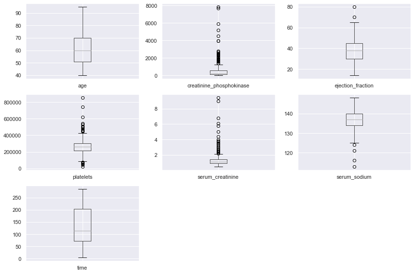

```python
# Plot para variaveis continuas

fig = plt.figure(figsize = (12, 8))

for i, col in enumerate(continuas):
    plt.subplot(3, 3, i + 1)
    heart.boxplot(col)
    plt.tight_layout()
```

Para uma melhor visualização iremos tentar transformar as variaveis continuas para log.

```python
heart[continuas] = np.log1p(1 + heart[continuas])
```

A transformação nos levou a alguns insights, como que a variavel 'time' pode possuir outliers se convertido em log, já outras variaveis como 'creatinine_phosphokinase' passam a não ter presença significativa de outliers.

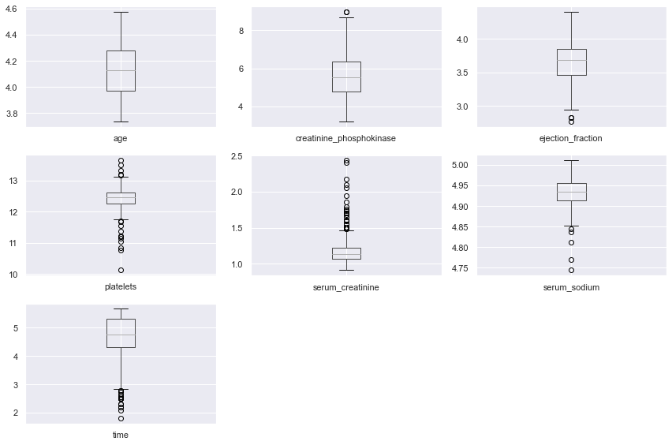

```python
# Plot para variaveis continuas

fig = plt.figure(figsize = (12, 8))

for i, col in enumerate(continuas):
    plt.subplot(3, 3, i + 1)
    heart.boxplot(col)
    plt.tight_layout()
```

```python
heart = heart_original.copy()
```

É notado que as variaveis continuas possuem uma tendência para inversamente proporcional, porém essa tendencia é fraca, mostrando valores quase que nulos para a correlação. É notado que a variavel 'creatinine_phosphokinase' e 'platelets' não aparentam possuir correlação com a variavel target.

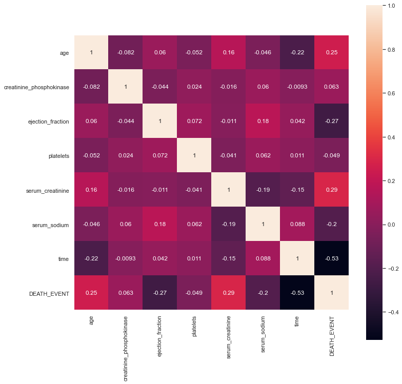

```python
# Mapa de calor das variaveis continuas
continuas_temp = continuas.copy()
continuas_temp.append('DEATH_EVENT')

plt.figure(figsize = (12, 12))
sns.heatmap(heart[continuas_temp].corr(method = 'pearson'), annot = True, square = True)
plt.show()
```

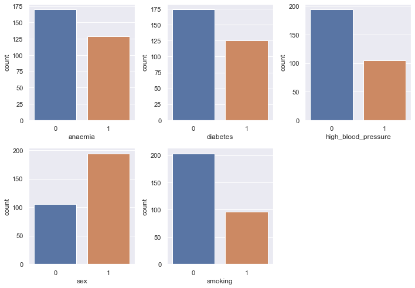

```python
# Countplot para variaveis categóricas

fig = plt.figure()
fig.subplots_adjust(hspace = 0.4, wspace = 0.4)
fig.set_figheight(7)
fig.set_figwidth(10)

for i, col in enumerate(categoricas):
    ax = fig.add_subplot(ceil(len(categoricas) / 3), 3, i + 1)
    sns.countplot(x = heart[col])

plt.tight_layout()
plt.show()
```

É verificado que o nosso dataset possui um desbalaneamento notavel, visto que aproximadamente 66% das variaveis é da classe 0 (não ocorreu falha cardiovascular) e 33% da classe 1 (ocorreu falha cardiovascular).

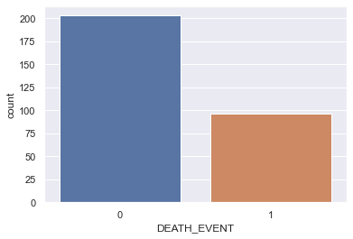

```python
# Countplot da variavel target
sns.countplot(x = heart['DEATH_EVENT'])
plt.show()
```

```python
print(Counter(heart['DEATH_EVENT']))
```

```
Counter({0: 203, 1: 96})
```

Para alguns insights iremos comparar a relação por um stacked barplot entre as variaveis categoricas e target. Para os graficos abaixo a grande surpresa fica no ultimo, 'smoking' onde é percebido que os não fumantes, classe 0, morrem mais que os fumantes, classe 1. Claro, isso é uma analise de somente uma métrica, para se ter certeza teriamos que analisar mais metricas.

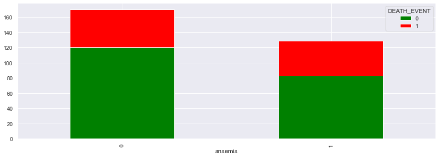

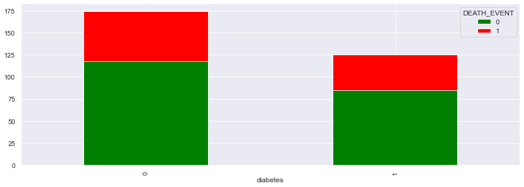

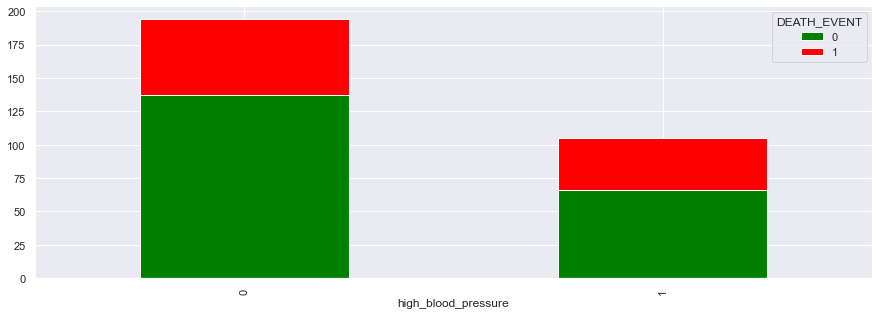

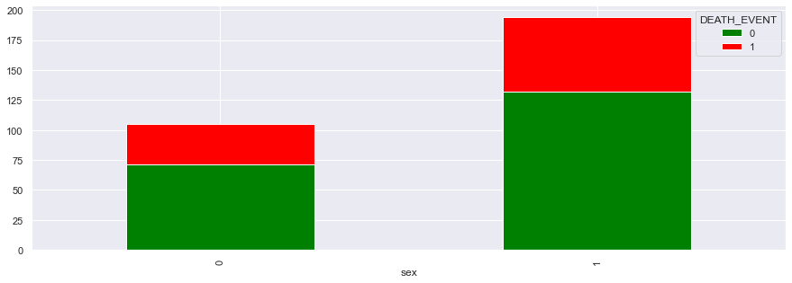

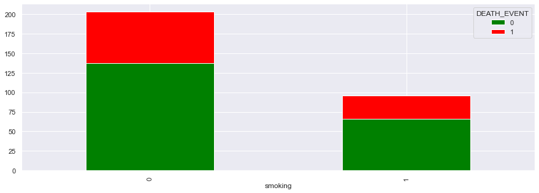

```python
for col in categoricas:
    pd.crosstab(heart[col], heart['DEATH_EVENT']).plot(kind = 'bar',
                                                       stacked = True,
                                                       figsize = (15, 5),
                                                       color = ['green', 'red'])
```

## 1.1 Distribuição dos Dados

Iremos verificar se os nossos dados possuem uma distribuição Gaussiana ou não. Dessa forma iremos entender quais metodos estatisticos utilizar. Distribuições Gaussianas utilizam de métodos estatisticos paramétricos. Já o contrário utiliza de métodos estatisticos não paramétricos. É importante entender qual método utilizar para não termos uma vissão errada sobre os dados.

```python
def quantil_quantil_teste(data, columns):

    for col in columns:
        print(col)
        qqplot(data[col], line = 's')
        plt.show()
```

Analisando as variaveis abaixo:

Age: Aparenta ser uma variavel com o comportamento Gaussiano, possui alguns pontos fora da linha mas nada muito grave.

creatinine_phosphokinase: Não apresenta comportamento Gaussiano, possui muitos pontos constantes e esta fora da linha de dados Gaussianos.

ejection_fraction: Possui um leve comportamento Gaussiano, os pontos tendem a seguir a reta, porém muitos pontos estão saindo da linha.

platelets: Possui forte comportamento Gaussiano, possui alguns pontos fora da linha mas nada grave.

serum_creatinine: Não apresenta comportamento Gaussiano, possui muitos pontos constantes e esta fora da linha de dados Gaussianos. Apesar disso parece seguir levemente a linha.

serum_sodium: Possui forte comportamento Gaussiano, possui alguns pontos fora da linha mas nada grave.

time: Apresenta fortes indicios de comportamento Gaussiano, porém os dados estão constantemente cruzando a reta.

```
age
```

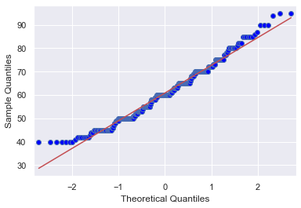

```
creatinine_phosphokinase
```

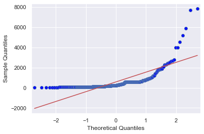

```
ejection_fraction
```

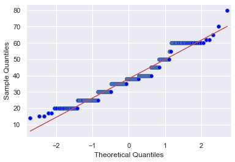

```
platelets
```

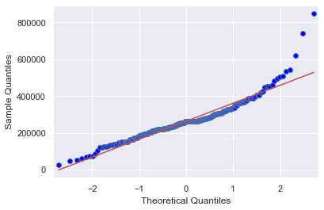

```
serum_creatinine
```

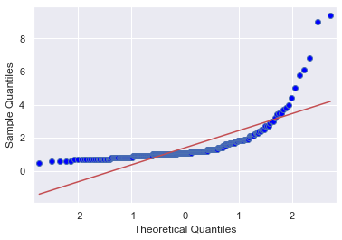

```
serum_sodium
```

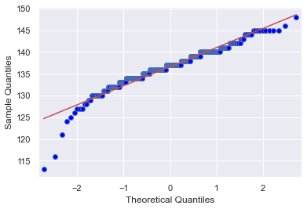

```
time
```

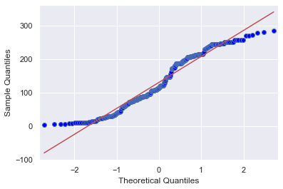

```python
quantil_quantil_teste(heart_original, continuas)
```

p <= alfa: Rejeita H0, dados não são Gaussianos.

p > alfa: Falha ao rejeitar H0, dados são Gaussianos.

```python
def testes_gaussianos(data, columns, teste):

    for i, col in enumerate(columns):
        print('Teste para a variavel', col)
        alpha = 0.05

        if teste == 'shapiro':
            stat, p = shapiro(data[col])
        elif teste == 'normal':
            stat, p = normaltest(data[col])
        elif teste == 'anderson':
            resultado = anderson(data[col])
            print('Stats: %.4f' % resultado.statistic)

            for j in range(len(resultado.critical_values)):
                sl, cv = resultado.significance_level[j], resultado.critical_values[j]

                if resultado.statistic < cv:
                    print('Significancia = %.4f, Valor Critico = %.4f, os dados parecem Gaussianos. Falha ao rejeitar H0.' % (sl, cv))
                else:
                    print('Significancia = %.4f, Valor Critico = %.4f, os dados não parecem Gaussianos. H0 rejeitado.' % (sl, cv))

        if teste != 'anderson':
            print('Stat = ', round(stat, 4))
            print('p-value = ', round(p, 4))
            #print('Stats = %4.f, p = %4.f' % (stat, p))

            if p > alpha:
                print('Os dados parecem Gaussianos. Falha ao rejeitar H0.')
            else:
                print('Os dados não parecem Gaussianos. H0 rejeitado.')

        print('\n')
```

### 1.1.1 Tesde de Shapiro Wilk

O teste de Shapiro Wilk é ideal para avaliar amostras ou conjuntos menores de dados, avaliando a probabilidade de que os dados tenham sido extraidos de uma distribuição Gaussiana.

```python
testes_gaussianos(heart, continuas, teste = 'shapiro')
```

```
Teste para a variavel age
Stat =  0.9755
p-value =  0.0001
Os dados não parecem Gaussianos. H0 rejeitado.


Teste para a variavel creatinine_phosphokinase
Stat =  0.5143
p-value =  0.0
Os dados não parecem Gaussianos. H0 rejeitado.


Teste para a variavel ejection_fraction
Stat =  0.9473
p-value =  0.0
Os dados não parecem Gaussianos. H0 rejeitado.


Teste para a variavel platelets
Stat =  0.9115
p-value =  0.0
Os dados não parecem Gaussianos. H0 rejeitado.


Teste para a variavel serum_creatinine
Stat =  0.5515
p-value =  0.0
Os dados não parecem Gaussianos. H0 rejeitado.


Teste para a variavel serum_sodium
Stat =  0.939
p-value =  0.0
Os dados não parecem Gaussianos. H0 rejeitado.


Teste para a variavel time
Stat =  0.9468
p-value =  0.0
Os dados não parecem Gaussianos. H0 rejeitado.
```

### 1.1.2 Teste normal de D'Agostino

O teste Normal de D'Agostino avalia se os dados são Gaussianos utilizando estatisticas resumidas como: Curtose e Skew.

```python
testes_gaussianos(heart, continuas, teste = 'normal')
```

```
Teste para a variavel age
Stat =  8.9515
p-value =  0.0114
Os dados não parecem Gaussianos. H0 rejeitado.


Teste para a variavel creatinine_phosphokinase
Stat =  307.1838
p-value =  0.0
Os dados não parecem Gaussianos. H0 rejeitado.


Teste para a variavel ejection_fraction
Stat =  14.1656
p-value =  0.0008
Os dados não parecem Gaussianos. H0 rejeitado.


Teste para a variavel platelets
Stat =  111.3375
p-value =  0.0
Os dados não parecem Gaussianos. H0 rejeitado.


Teste para a variavel serum_creatinine
Stat =  307.903
p-value =  0.0
Os dados não parecem Gaussianos. H0 rejeitado.


Teste para a variavel serum_sodium
Stat =  74.3649
p-value =  0.0
Os dados não parecem Gaussianos. H0 rejeitado.


Teste para a variavel time
Stat =  174.7684
p-value =  0.0
Os dados não parecem Gaussianos. H0 rejeitado.
```

## 1.2 Tabela de Contigencia

```python
def crosstab_column(data, col, target, percentage = True):
    res = pd.crosstab(data[col], data[target], margins = True)

    if percentage:
        res = pd.crosstab(data[col], data[target], margins = True, normalize = 'index').round(4) * 100

    return res
```

Analisando a tabela de contigência abaixo não é possível afirmar se uma variavel categorica possui relação para a classificação da variavel target. Para confirmarmos as nossas hipoteses, iremos seguir para a Correlação de Spearman e Qui-Quadrado.

```python
for col in categoricas:
    print(crosstab_column(heart, col, 'DEATH_EVENT'), end = '\n\n\n')
```

```
DEATH_EVENT      0      1
anaemia
0            70.59  29.41
1            64.34  35.66
All          67.89  32.11


DEATH_EVENT      0      1
diabetes
0            67.82  32.18
1            68.00  32.00
All          67.89  32.11


DEATH_EVENT              0      1
high_blood_pressure
0                    70.62  29.38
1                    62.86  37.14
All                  67.89  32.11


DEATH_EVENT      0      1
sex
0            67.62  32.38
1            68.04  31.96
All          67.89  32.11


DEATH_EVENT      0      1
smoking
0            67.49  32.51
1            68.75  31.25
All          67.89  32.11
```

## 1.3 Correlação de Spearman

```python
def coefSpearman(data, col, target):
    for c in col:
        coeficiente, p_valor = stats.spearmanr(data[c], data[target])
        print("Correlação de Spearman entre a variavel", target, "e a variavel continua", c, ": {:0.4}".format(coeficiente))
```

```python
coefSpearman(heart, continuas, 'DEATH_EVENT')
```

```
Correlação de Spearman entre a variavel DEATH_EVENT e a variavel continua age : 0.2181
Correlação de Spearman entre a variavel DEATH_EVENT e a variavel continua creatinine_phosphokinase : 0.02362
Correlação de Spearman entre a variavel DEATH_EVENT e a variavel continua ejection_fraction : -0.2869
Correlação de Spearman entre a variavel DEATH_EVENT e a variavel continua platelets : -0.0462
Correlação de Spearman entre a variavel DEATH_EVENT e a variavel continua serum_creatinine : 0.3706
Correlação de Spearman entre a variavel DEATH_EVENT e a variavel continua serum_sodium : -0.2098
Correlação de Spearman entre a variavel DEATH_EVENT e a variavel continua time : -0.5432
```

## 1.4 QUI-QUADRADO

```python
def qui2(data, col, target):
    for c in col:
        cross = pd.crosstab(data[c], data[target])
        chi2, p, dof, exp = stats.chi2_contingency(cross)
        print("Qui-quadrado entre a variavel", target, "e a variavel categorica", c, ": {:0.4}".format(chi2))
        print("Apresentando um p-value de: {:0.4}".format(p), end = '\n\n')
```

Comparando o p-value para as variaveis categorigas nós não conseguimos rejeitar a hipotese nula, concluindo que as nossas variaveis não estão correlacionadas com a target.

```python
qui2(heart, categoricas, 'DEATH_EVENT')
```

```
Qui-quadrado entre a variavel DEATH_EVENT e a variavel categorica anaemia : 1.042
Apresentando um p-value de: 0.3073

Qui-quadrado entre a variavel DEATH_EVENT e a variavel categorica diabetes : 0.008458
Apresentando um p-value de: 0.9267

Qui-quadrado entre a variavel DEATH_EVENT e a variavel categorica high_blood_pressure : 1.543
Apresentando um p-value de: 0.2141

Qui-quadrado entre a variavel DEATH_EVENT e a variavel categorica sex : 0.003037
Apresentando um p-value de: 0.9561

Qui-quadrado entre a variavel DEATH_EVENT e a variavel categorica smoking : 0.007331
Apresentando um p-value de: 0.9318
```

## 1.5 Cox Proportional Hazards

Iremos utilizar o algoritmo de Cox Proportional Hazards, já que é famoso por associar as variaveis preditoras corretas para aumentar a chance de sobrevivencia de um individuo. Esse algoritmo é amplamente utilizado para dados médicos, sendo assim irá ser traçado a chance de sobrevivencia pelo tempo.

O dataset utilizado possui uma variavel 'time', essa que mede o tempo da ultima consulta do paciente até a falha cardiovascular. Já que essa variavel não irá ser utilizada no dataset final, visto que não iremos saber quando o paciente irá morrer, iremos utiliza-la antes para associar as variaveis.

```python
cph = CoxPHFitter()
```

```python
cph.fit(heart, event_col = 'DEATH_EVENT', duration_col = 'time')
```

```
<lifelines.CoxPHFitter: fitted with 299 total observations, 203 right-censored observations>
```

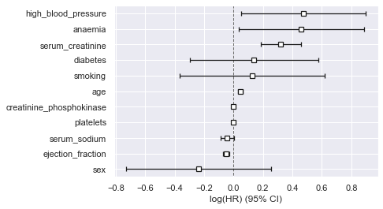

```python
cph.plot()
```

Abaixo possuimos um resumo estatistico apresentado pelo modelo:

Valores de 'p' onde (p < 0.05) indicam que as outras colunas possuem uma avaliação confiavel e possuem uma boa significancia para o modelo.

Altos valores de 'coef' indicam que o aumento dessa variavel leva ao aumento do risco de falha cardiovascular. É perceptivel esses valores para a variavel 'anaemia', 'high_blood_pressure' e 'serum_creatinine'.

O valor de 'coef', 'exp(coef)', 'exp(coef) lower 95%' e 'exp(coef) upper 95%' estão relacionados do maior valor para o menor. Por exemplo 'anaemia' é uma variavel categorica com valor 1 e 0. Então estamos relacionando a chance de ter anaemia (1) com a chance de não ter (0).

O que significa que para a variavel 'coef' o seu aumento, valor 1, aumenta o risco de falha cardiovascular.

O atributo 'exp(coef)' indica a relação de riscos covariaods a variavel. De forma que o aumento daquela variavel aponta um risco Y em um fator X, X = 'exp(coef)'. Por exemplo a variavel 'Anaemia' tem que o seu aumento é prejudicial de acordo com 'coef', e temos em 'exp(coef)' que o seu aumento é prejudicial em um fator de 58% (1 - 1.58), por outra lado a sua diminuição é 42% benéfica (1 - 0.58).

Os atributos 'exp(coef) lower 95%' e 'exp(coef) upper 95%' indicam os seus intervalos de confiança.

Já para os atributos globais, possuimos uma 'concordance' alta, o que é bom. Seguindo para 'Partial AIC' percebe-se que o modelo utilizado não apresenta resultados muito bons. Porém olhando para o 'log-likelihood ratio test' nos indica que modelos do mesmo tipo tem um ganho significativo se bem parametrizados.

```python
cph.print_summary(columns=["coef", "exp(coef)", "exp(coef) lower 95%", "exp(coef) upper 95%", "z", "p"], decimals = 4)
```

| model | lifelines.CoxPHFitter |
| --- | --- |
| duration col | 'time' |
| event col | 'DEATH_EVENT' |
| baseline estimation | breslow |
| number of observations | 299 |
| number of events observed | 96 |
| partial log-likelihood | -468.2279 |
| time fit was run | 2021-07-11 19:59:40 UTC |

|  | coef | exp(coef) | exp(coef) lower 95% | exp(coef) upper 95% | z | p |
| --- | --- | --- | --- | --- | --- | --- |
| age | 0.0464 | 1.0475 | 1.0285 | 1.0668 | 4.9773 | <5e-05 |
| anaemia | 0.4601 | 1.5843 | 1.0358 | 2.4233 | 2.1220 | 0.0338 |
| creatinine_phosphokinase | 0.0002 | 1.0002 | 1.0000 | 1.0004 | 2.2255 | 0.0260 |
| diabetes | 0.1399 | 1.1501 | 0.7427 | 1.7811 | 0.6269 | 0.5307 |
| ejection_fraction | -0.0489 | 0.9522 | 0.9329 | 0.9720 | -4.6719 | <5e-05 |
| high_blood_pressure | 0.4757 | 1.6092 | 1.0534 | 2.4583 | 2.2005 | 0.0278 |
| platelets | -0.0000 | 1.0000 | 1.0000 | 1.0000 | -0.4116 | 0.6806 |
| serum_creatinine | 0.3210 | 1.3786 | 1.2014 | 1.5818 | 4.5751 | <5e-05 |
| serum_sodium | -0.0442 | 0.9568 | 0.9141 | 1.0014 | -1.8993 | 0.0575 |
| sex | -0.2375 | 0.7886 | 0.4816 | 1.2913 | -0.9440 | 0.3452 |
| smoking | 0.1289 | 1.1376 | 0.6953 | 1.8614 | 0.5132 | 0.6078 |

| Concordance | 0.7408 |
| --- | --- |
| Partial AIC | 958.4557 |
| log-likelihood ratio test | 81.9545 on 11 df |
| -log2(p) of ll-ratio test | 40.5590 |

Analisando as chances de sobrevivencias de dois individuos, percebemos que claramente o tempo é um fator decisivo na sua chance de sobrevivência.

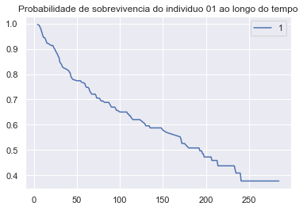

```python
cph.predict_survival_function(heart.loc[1]).plot(title="Probabilidade de sobrevivencia do individuo 01 ao longo do tempo")
```

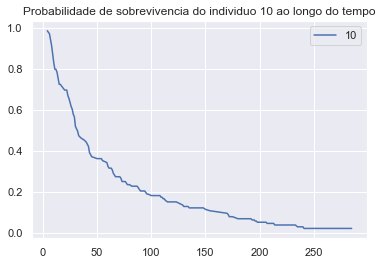

```python
cph.predict_survival_function(heart.loc[10]).plot(title="Probabilidade de sobrevivencia do individuo 10 ao longo do tempo")
```

Abaixo é realizado uma analise cada variavel de forma individual, de forma que o nosso objetivo é ver o impacto de cara variavel desconsiderando as outras. Assim, o ideal é olhar para as variaveis de forma unificada como foi feito anteriormente olhando o resumo estatistico.

É claramente perceptivel que aumentando a idade do individuo as suas chances de sobrevivencia são menores ao longo do tempo.

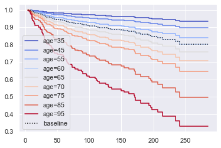

```python
cph.plot_partial_effects_on_outcome(covariates = 'age', values = [35, 45, 55, 60, 65, 70, 75, 85, 95], cmap = 'coolwarm')
```

É perceptivel que a maioria das pessoas com CPK no sangue até 1000 mcg/L possuem chances de sobrevivencia similares, porém com o seu aumento para 2000 já temos um grande pulo de menos 10% na chance de sobrevivencia, já para 4000 o nosso pulo é de mais de 20%.

O que faz total sentido já que um exame normal deve constar valores entre 10 e 120 mcg/L no sangue. Valores alto constumam indicar riscos de ataqque cardiaco, convulsão, delirio...

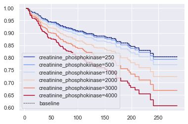

```python
cph.plot_partial_effects_on_outcome(covariates = 'creatinine_phosphokinase', values = [250, 500, 1000, 2000, 3000, 4000],\
                                    cmap = 'coolwarm')
```

Já a variavel 'ejection_fraction' é proporcinal as chances de sobrevivencia, ou seja seu aumento é positivo para o individuo, é esperado taxas entre 50% e 75%. Menos que 50% começa a apresentar riscos a saude, e abaixo de 40% apresenta graves riscos.

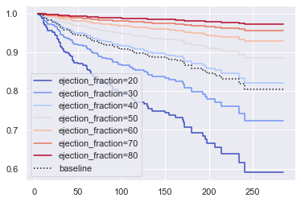

```python
cph.plot_partial_effects_on_outcome(covariates = 'ejection_fraction', values = [20, 30, 40, 50, 60, 70, 80], cmap = 'coolwarm')
```

Contudo é perceptivel que a variavel 'platelets' não possui grande significancia tanto para o aujmento ou diminuição nas chances de sobrevivencia do individuo.

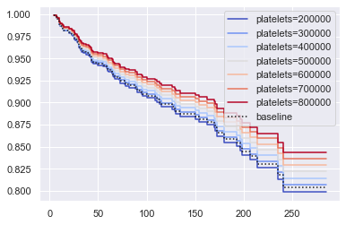

```python
cph.plot_partial_effects_on_outcome(covariates = 'platelets',\
                                    values = [200000, 300000, 400000, 500000, 600000, 700000, 800000],\
                                    cmap = 'coolwarm')
```

Isso é totalmente normal, visto que o normal é um resultado entre 0.74 e 1.35 mg/dl para homens e 0.59 a 1.04 mg/dl para mulheres. Qualquer valor fora dessas margens já começa a ser preocupante, apresentando sinais de má função renal.

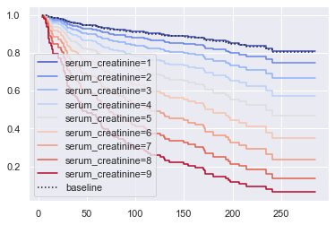

```python
cph.plot_partial_effects_on_outcome(covariates = 'serum_creatinine', values = [1, 2, 3, 4, 5, 6, 7, 8, 9], cmap = 'coolwarm')
```

Por outro lado a variavel 'serum_sodium' aparenta possuir uma relação moderada com nosso alvo, considerando que valores maiores aumentam a taxa de sobrevivencia. Sendo esperado em um resultado normal valores entre 135 e 145 mEq/L. Sendo preocupante valores menores que 135 mEq/L, indicando riscos de fadiga, nausea, perda de consciência e até coma.

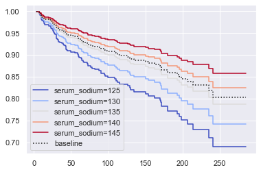

```python
cph.plot_partial_effects_on_outcome(covariates = 'serum_sodium', values = [125, 130, 135, 140, 145], cmap = 'coolwarm')
```

```python
def plot_partial_categorical(cph_, columns):
    for column in columns:
        cph_.plot_partial_effects_on_outcome(covariates = column, values = [0, 1], cmap = 'coolwarm')
```

Visualizando a regressão para os dados categoricos é perceptivel que algumas variaveis não possuem tanto impacto em relação a outras.

A variavel 'Anaemia' possui ganho significativo. Pessoas sem 'Anaemia' possuem 10% a mais de chance de sobreviver.

A variavel 'Diabetes' não possui ganho significativo. Pessoas com 'Diabetes' não possuem chances muito maior de sobrevivencia.

A variavel 'high_blood_pressure' possui ganho significativo. Pessoas sem 'high_blood_pressure' possuem 10% a mais de chance de sobreviver.

A variavel 'sex' possui ganho pequeno. Pessoas do 'sex' 0 (Feminino) possuem 5% a menos de chance de sobreviver o 'sex' 1 (Masculino).

A variavel 'Smokinng' não possui ganho significativo. Pessoas que fumam não possuem chances muito maiores de sobrevivencia.

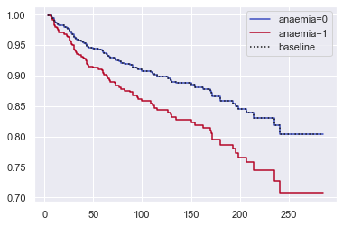

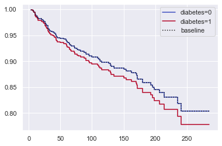

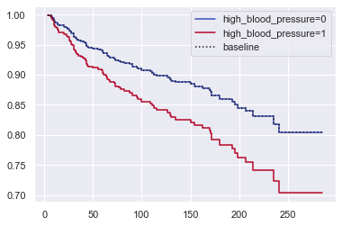

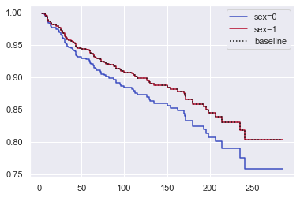

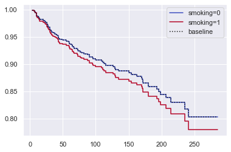

```python
plot_partial_categorical(cph, categoricas)
```

Devido ao time ser uma variavel que possui valores inexistentes em um cenario real, irá ser removida do dataset.

```python
continuas.remove('time')
heart = heart.drop('time', axis = 1)
heart.head()
```

|  | age | anaemia | creatinine_phosphokinase | diabetes | ejection_fraction | high_blood_pressure | platelets | serum_creatinine | serum_sodium | sex | smoking | DEATH_EVENT |
| --- | --- | --- | --- | --- | --- | --- | --- | --- | --- | --- | --- | --- |
| 0 | 75.0 | 0 | 582 | 0 | 20 | 1 | 265000.00 | 1.9 | 130 | 1 | 0 | 1 |
| 1 | 55.0 | 0 | 7861 | 0 | 38 | 0 | 263358.03 | 1.1 | 136 | 1 | 0 | 1 |
| 2 | 65.0 | 0 | 146 | 0 | 20 | 0 | 162000.00 | 1.3 | 129 | 1 | 1 | 1 |
| 3 | 50.0 | 1 | 111 | 0 | 20 | 0 | 210000.00 | 1.9 | 137 | 1 | 0 | 1 |
| 4 | 65.0 | 1 | 160 | 1 | 20 | 0 | 327000.00 | 2.7 | 116 | 0 | 0 | 1 |

# 2. Avaliando a MultiColinearidade

```python
X = heart.iloc[:, :-1]
y = heart['DEATH_EVENT'].values
columns = heart.keys()
```

## 2.1 Autovetores

```python
X.head()
```

|  | age | anaemia | creatinine_phosphokinase | diabetes | ejection_fraction | high_blood_pressure | platelets | serum_creatinine | serum_sodium | sex | smoking |
| --- | --- | --- | --- | --- | --- | --- | --- | --- | --- | --- | --- |
| 0 | 75.0 | 0 | 582 | 0 | 20 | 1 | 265000.00 | 1.9 | 130 | 1 | 0 |
| 1 | 55.0 | 0 | 7861 | 0 | 38 | 0 | 263358.03 | 1.1 | 136 | 1 | 0 |
| 2 | 65.0 | 0 | 146 | 0 | 20 | 0 | 162000.00 | 1.3 | 129 | 1 | 1 |
| 3 | 50.0 | 1 | 111 | 0 | 20 | 0 | 210000.00 | 1.9 | 137 | 1 | 0 |
| 4 | 65.0 | 1 | 160 | 1 | 20 | 0 | 327000.00 | 2.7 | 116 | 0 | 0 |

Para avaliarmos a multicolinearidade iremos utilizar de correlação e atribuir aos metodos de autovetores. Onde iremos ter a variancia acumulada entre as variaveis. Para esse avaliação iremos utilizar somente as variaveis continuas.

```python
corr = np.corrcoef(X[continuas], rowvar = 0)
eigenvalues, eigenvectors = np.linalg.eig(corr)
```

```python
print(eigenvalues, min(eigenvalues))
```

```
[1.34527211 1.15364884 0.72934891 0.82384075 0.96051258 0.98737681] 0.7293489113371818
```

```python
print(abs(eigenvectors[:, 2]))
```

```
[0.18085313 0.23800393 0.41537521 0.02737793 0.54333596 0.66494074]
```

```python
print(continuas[0], continuas[1], continuas[2], continuas[4], continuas[5])
```

```
age creatinine_phosphokinase ejection_fraction serum_creatinine serum_sodium
```